# Synthesis: Which Functions Does Each Cell-Type Pair’s LR List Point To?

KEGG pathway membership (04) and STRING GO Biological Process enrichment (05), combined into one spatial_pair x function view

Published

October 9, 2026

## 1 Overview

Combines the exports of `04` (KEGG pathway membership) and `05` (STRING GO Biological Process enrichment on the whole curated gene set) into one table of (`spatial_pair`, gene, function), and summarises which functions each cell-type pair’s significant LR genes point to.

Outputs:

- `function_convergence` – every function, with how many `spatial_pair`s and genes hit it;
- `pair_summary` – top functions per `spatial_pair`;
- a heatmap of `spatial_pair` x function, for functions shared by 2+ pairs that are concentrated in one or a few of them.

Run `04` and `05` first.

```r
library(dplyr)
library(tibble)
library(ggplot2)
```

## 2 Load exports

```r
kegg_gene_pathway     <- read.csv(file.path("output", "04_KEGG_PathwayConvergence", "kegg_gene_pathway_by_pair.csv"), stringsAsFactors = FALSE)
string_enrichment_all <- read.csv(file.path("output", "05_STRING_NetworkAnalysis", "string_whole_network_enrichment.csv"), stringsAsFactors = FALSE)
```

`spatial_pair` per gene is rebuilt from `significant_lr_pairs.csv`.

```r
split_complex <- function(x) stringr::str_split(x, "_")

sig_pairs <- read.csv(file.path("output", "03c_crossModality_plots", "significant_lr_pairs.csv"), stringsAsFactors = FALSE) %>%
  distinct(spatial_pair, ligand_complex, receptor_complex)

lr_gene_sets <- purrr::pmap(sig_pairs, function(spatial_pair, ligand_complex, receptor_complex) {
  ligands   <- unlist(split_complex(ligand_complex))
  receptors <- unlist(split_complex(receptor_complex))
  tibble(spatial_pair = spatial_pair, gene = unique(c(ligands, receptors)))
})

lr_genes_long <- bind_rows(lr_gene_sets) %>% distinct(spatial_pair, gene)
lr_genes_long
```

| spatial_pair | gene |
| --- | --- |
| Astrocyte-Vascular | Ptn |
| Astrocyte-Vascular | Sdc4 |
| Astrocyte-Vascular | Ptprs |
| Astrocyte-Vascular | Fgfr3 |
| Astrocyte-Vascular | Epha4 |
| Astrocyte-Vascular | Cxcl12 |
| Astrocyte-Vascular | Itgb1 |
| Astrocyte-Vascular | Mif |
| Astrocyte-Vascular | Ackr3 |
| Astrocyte-Vascular | Vtn |

[output cut: 59 more lines]

## 3 STRING GO Biological Process membership

GO Biological Process terms from the STRING enrichment, with the genes supporting each term.

```r
fdr_col   <- intersect(c("fdr", "false_discovery_rate", "p_value"), names(string_enrichment_all))[1]
cat_col   <- intersect(c("category"), names(string_enrichment_all))[1]
desc_col  <- intersect(c("description"), names(string_enrichment_all))[1]
term_col  <- intersect(c("term"), names(string_enrichment_all))[1]
genes_col <- intersect(c("preferredNames", "inputGenes", "genes"), names(string_enrichment_all))[1]

if (is.na(cat_col) || is.na(genes_col) || is.na(term_col) || is.na(desc_col)) {
  stop("Couldn't find the expected columns in string_whole_network_enrichment.csv. ",
       "Columns present: ", paste(names(string_enrichment_all), collapse = ", "))
}

string_process_gene <- string_enrichment_all %>%
  dplyr::filter(.data[[cat_col]] == "Process") %>%
  transmute(
    function_id   = .data[[term_col]],
    function_name = .data[[desc_col]],
    fdr           = .data[[fdr_col]],
    gene          = stringr::str_split(.data[[genes_col]], ",\\s*")
  ) %>%
  tidyr::unnest(gene) %>%
  distinct(function_id, function_name, gene)

string_process_gene
```

| function_id | function_name | gene |
| --- | --- | --- |
| GO:0048583 | Regulation of response to stimulus | Pdgfb |
| GO:0048583 | Regulation of response to stimulus | Efnb2 |
| GO:0048583 | Regulation of response to stimulus | App |
| GO:0048583 | Regulation of response to stimulus | Nid1 |
| GO:0048583 | Regulation of response to stimulus | Aplp1 |
| GO:0048583 | Regulation of response to stimulus | Vtn |
| GO:0048583 | Regulation of response to stimulus | Vegfb |
| GO:0048583 | Regulation of response to stimulus | Nrp1 |
| GO:0048583 | Regulation of response to stimulus | Epha4 |
| GO:0048583 | Regulation of response to stimulus | Itgav |

[output cut: 6018 more lines]

## 4 Drop overly generic GO terms

Broad terms near the top of the GO hierarchy (“regulation of cellular process”) are enriched in almost any gene set. Terms with more than `max_background_genes` genes genome-wide are removed.

```r
bg_col <- intersect(
  c("number_of_genes_in_background", "background_gene_count", "bgCount", "genesInBackground"),
  names(string_enrichment_all)
)[1]

if (is.na(bg_col)) {

  message("No genome-wide background-size column found -- specificity filter skipped.")

} else {

  process_bg <- string_enrichment_all %>%
    dplyr::filter(.data[[cat_col]] == "Process") %>%
    dplyr::transmute(function_id = .data[[term_col]], background_size = .data[[bg_col]])

  max_background_genes <- 300   # lower = only more specific terms survive

  q <- stats::quantile(process_bg$background_size, probs = c(0, 0.25, 0.5, 0.75, 1))
  n_before <- dplyr::n_distinct(process_bg$function_id)
  keep_ids <- process_bg %>% dplyr::filter(background_size <= max_background_genes) %>% dplyr::pull(function_id)
  n_after  <- length(unique(keep_ids))

  message(
    "Term size quantiles (", n_before, " terms): ",
    paste(names(q), q, sep = " = ", collapse = ", "),
    ". Keeping <= ", max_background_genes, " genes: ", n_after, " of ", n_before, " terms."
  )

  string_process_gene <- string_process_gene %>% dplyr::filter(function_id %in% keep_ids)
}

string_process_gene
```

| function_id | function_name | gene |
| --- | --- | --- |
| GO:0070374 | Positive regulation of ERK1 and ERK2 cascade | Pdgfb |
| GO:0070374 | Positive regulation of ERK1 and ERK2 cascade | App |
| GO:0070374 | Positive regulation of ERK1 and ERK2 cascade | Vegfb |
| GO:0070374 | Positive regulation of ERK1 and ERK2 cascade | Nrp1 |
| GO:0070374 | Positive regulation of ERK1 and ERK2 cascade | Mif |
| GO:0070374 | Positive regulation of ERK1 and ERK2 cascade | Lrp1 |
| GO:0070374 | Positive regulation of ERK1 and ERK2 cascade | Gnai2 |
| GO:0070374 | Positive regulation of ERK1 and ERK2 cascade | Ackr3 |
| GO:0070374 | Positive regulation of ERK1 and ERK2 cascade | Cxcl12 |
| GO:0070374 | Positive regulation of ERK1 and ERK2 cascade | Pdgfa |

[output cut: 1420 more lines]

## 5 Collapse STRING terms with identical gene evidence

Nested GO terms (“regulation of X”, “positive regulation of X”) are often supported by exactly the same genes. Terms with an identical set of `spatial_pair`:gene evidence are merged into one row, named after the shortest term.

```r
string_gene_level <- string_process_gene %>%
  inner_join(lr_genes_long, by = "gene", relationship = "many-to-many") %>%
  distinct(spatial_pair, gene, function_id, function_name)

string_signature <- string_gene_level %>%
  mutate(evidence = paste0(spatial_pair, ":", gene)) %>%
  group_by(function_id, function_name) %>%
  summarise(signature = paste(sort(unique(evidence)), collapse = "|"), .groups = "drop")

string_signature_groups <- string_signature %>%
  group_by(signature) %>%
  summarise(
    n_terms              = n(),
    term_names           = paste(sort(function_name), collapse = "; "),
    representative_id    = function_id[which.min(nchar(function_name))],
    representative_name  = function_name[which.min(nchar(function_name))],
    .groups = "drop"
  ) %>%
  arrange(desc(n_terms))

string_id_to_group <- string_signature %>%
  left_join(
    string_signature_groups %>% dplyr::select(signature, representative_id, representative_name, n_terms),
    by = "signature"
  )

string_signature_groups %>% dplyr::select(representative_name, n_terms, term_names)
```

| representative_name | n_terms | term_names |
| --- | --- | --- |
| Lipoprotein catabolic process | 4 | High-density lipoprotein particle clearance; Lipoprotein catabolic process; Negative regulation of amyloid fibril formation; Response to caloric restriction |
| Suckling behavior | 4 | Cellular copper ion homeostasis; Regulation of cellular protein metabolic process; Regulation of epidermal growth factor-activated receptor activity; Suckling behavior |
| Estrous cycle | 4 | Estrous cycle; Leukocyte chemotaxis involved in inflammatory response; Positive regulation of hepatocyte proliferation; Response to auditory stimulus |
| Positive regulation of protein autophosphorylation | 3 | Negative regulation of phosphatidylinositol biosynthetic process; Positive regulation of metanephric mesenchymal cell migration by platelet-derived growth factor receptor-beta signaling pathway; Posit… |
| Negative regulation of dendritic spine maintenance | 2 | Negative regulation of dendritic spine maintenance; Positive regulation of membrane protein ectodomain proteolysis |
| Viral process | 2 | Biological process involved in symbiotic interaction; Viral process |
| Regulation of neurofibrillary tangle assembly | 2 | Negative regulation of triglyceride metabolic process; Regulation of neurofibrillary tangle assembly |
| Neuron remodeling | 2 | Negative regulation of miRNA transcription; Neuron remodeling |
| Response to organophosphorus | 2 | Response to organophosphorus; Response to purine-containing compound |
| Positive regulation of NIK/NF-kappaB signaling | 2 | Positive regulation of interferon-gamma production; Positive regulation of NIK/NF-kappaB signaling |

[output cut: 321 more lines]

## 6 Reduce STRING terms by semantic similarity (rrvgo)

Merges GO terms that are closely related in the GO graph even if their genes differ slightly (`rrvgo`, the method behind REVIGO). The most significant term (lowest FDR) names each group. Needs `rrvgo`, `GOSemSim` and `org.Mm.eg.db`.

```r
if (!requireNamespace("BiocManager", quietly = TRUE)) install.packages("BiocManager")
for (pkg in c("rrvgo", "GOSemSim", "org.Mm.eg.db")) {
  if (!requireNamespace(pkg, quietly = TRUE)) BiocManager::install(pkg, update = FALSE, ask = FALSE)
}

rep_terms <- string_signature_groups %>% dplyr::distinct(representative_id, representative_name)

# -log10(FDR): higher score = preferred as group label
term_fdr <- string_enrichment_all %>%
  dplyr::filter(.data[[cat_col]] == "Process") %>%
  dplyr::transmute(function_id = .data[[term_col]], fdr = .data[[fdr_col]])

scores <- term_fdr$fdr[match(rep_terms$representative_id, term_fdr$function_id)]
scores <- setNames(-log10(pmax(scores, 1e-300)), rep_terms$representative_id)

simMatrix <- rrvgo::calculateSimMatrix(
  rep_terms$representative_id,
  orgdb  = "org.Mm.eg.db",
  ont    = "BP",
  method = "Rel"
)

semantic_similarity_threshold <- 0.7   # rrvgo: 0.9 large, 0.7 medium, 0.5 small, 0.4 tiny groups

reduced_terms <- rrvgo::reduceSimMatrix(
  simMatrix,
  scores[rownames(simMatrix)],
  threshold = semantic_similarity_threshold,
  orgdb     = "org.Mm.eg.db"
)

string_semantic_group <- tibble::as_tibble(reduced_terms) %>%
  dplyr::transmute(representative_id = go, semantic_parent_id = parent, semantic_parent_name = parentTerm)

# every raw GO term now maps to one final group (identical-evidence + semantic merging)
string_id_to_group <- string_id_to_group %>%
  dplyr::left_join(string_semantic_group, by = "representative_id") %>%
  dplyr::mutate(
    final_id   = dplyr::coalesce(semantic_parent_id, representative_id),
    final_name = dplyr::coalesce(semantic_parent_name, representative_name)
  )

final_group_sizes <- string_id_to_group %>% dplyr::count(final_id, name = "n_terms_final")

string_id_to_group <- string_id_to_group %>%
  dplyr::select(-n_terms) %>%
  dplyr::left_join(final_group_sizes, by = "final_id") %>%
  dplyr::rename(n_terms = n_terms_final)

string_id_to_group %>%
  dplyr::distinct(final_name, n_terms) %>%
  dplyr::arrange(dplyr::desc(n_terms))
```

| final_name | n_terms |
| --- | --- |
| gliogenesis | 24 |
| regulation of leukocyte migration | 22 |
| positive regulation of neurogenesis | 21 |
| regulation of endocytosis | 12 |
| regulation of peptidyl-tyrosine phosphorylation | 12 |
| positive regulation of epithelial cell proliferation | 11 |
| negative regulation of cell projection organization | 11 |
| regulation of interleukin-6 production | 11 |
| sprouting angiogenesis | 10 |
| regulation of chemotaxis | 10 |

[output cut: 50 more lines]

## 7 Collapse KEGG pathways with identical gene evidence

Hub genes sit in dozens of KEGG maps, many of them disease or infection maps, so the same few genes repeat across many pathways. Pathways with identical `spatial_pair`:gene evidence are merged into one row.

```r
kegg_gene_level <- kegg_gene_pathway %>%
  distinct(spatial_pair, gene, pathway_id, pathway_name)

kegg_signature <- kegg_gene_level %>%
  mutate(evidence = paste0(spatial_pair, ":", gene)) %>%
  group_by(pathway_id, pathway_name) %>%
  summarise(signature = paste(sort(unique(evidence)), collapse = "|"), .groups = "drop")

kegg_signature_groups <- kegg_signature %>%
  group_by(signature) %>%
  summarise(
    n_pathways           = n(),
    pathway_names        = paste(sort(pathway_name), collapse = "; "),
    representative_id    = pathway_id[which.min(nchar(pathway_name))],
    representative_name  = pathway_name[which.min(nchar(pathway_name))],
    .groups = "drop"
  ) %>%
  arrange(desc(n_pathways))

kegg_id_to_group <- kegg_signature %>%
  left_join(
    kegg_signature_groups %>% dplyr::select(signature, representative_id, representative_name, n_pathways),
    by = "signature"
  )

kegg_signature_groups %>% dplyr::select(representative_name, n_pathways, pathway_names)
```

| representative_name | n_pathways | pathway_names |
| --- | --- | --- |
| Oocyte meiosis | 14 | Amphetamine addiction; C-type lectin receptor signaling pathway; Cellular senescence; Glucagon signaling pathway; GnRH signaling pathway; Inflammatory mediator regulation of TRP channels; Insulin sign… |
| Alcoholism | 12 | Adrenergic signaling in cardiomyocytes; Alcoholism; Apelin signaling pathway; cAMP signaling pathway; cGMP-PKG signaling pathway; Circadian entrainment; Dopaminergic synapse; Gastric acid secretion; M… |
| Chagas disease | 10 | Chagas disease; Cholinergic synapse; Cocaine addiction; GABAergic synapse; Growth hormone synthesis, secretion and action; Long-term depression; Morphine addiction; Progesterone-mediated oocyte matura… |
| Virion | 5 | Bacterial invasion of epithelial cells; Leishmaniasis; Tight junction; Virion; Yersinia infection |
| Virion | 5 | Bile secretion; Cortisol synthesis and secretion; Hepatitis C; Ovarian steroidogenesis; Virion |
| Amoebiasis | 5 | Acute myeloid leukemia; Alcoholic liver disease; Amoebiasis; Hematopoietic cell lineage; Legionellosis |
| Measles | 4 | Influenza A; Lysosome biogenesis; Measles; Neutrophil extracellular trap formation |
| Dilated cardiomyopathy | 3 | Arrhythmogenic right ventricular cardiomyopathy; Dilated cardiomyopathy; Hypertrophic cardiomyopathy |
| Metabolic pathways | 3 | Metabolic pathways; Phenylalanine metabolism; Tyrosine metabolism |
| Melanoma | 3 | Choline metabolism in cancer; JAK-STAT signaling pathway; Melanoma |

[output cut: 77 more lines]

## 8 Combined (spatial_pair, gene, function) table

Merged groups are labelled “name (+N more)”.

```r
kegg_long <- kegg_gene_level %>%
  left_join(
    kegg_id_to_group %>% dplyr::select(pathway_id, representative_id, representative_name, n_pathways),
    by = "pathway_id"
  ) %>%
  transmute(
    function_source = "KEGG pathway",
    function_id     = representative_id,
    function_name   = if_else(
      n_pathways > 1,
      paste0(representative_name, " (+", n_pathways - 1, " more)"),
      representative_name
    ),
    spatial_pair,
    gene
  ) %>%
  distinct()

string_long <- string_gene_level %>%
  left_join(
    string_id_to_group %>% dplyr::select(function_id, final_id, final_name, n_terms),
    by = "function_id"
  ) %>%
  transmute(
    function_source = "STRING: Biological Process",
    function_id     = final_id,
    function_name   = if_else(
      n_terms > 1,
      paste0(final_name, " (+", n_terms - 1, " more)"),
      final_name
    ),
    spatial_pair,
    gene
  ) %>%
  distinct()

function_by_pair_long <- bind_rows(kegg_long, string_long)
function_by_pair_long
```

| function_source | function_id | function_name | spatial_pair | gene |
| --- | --- | --- | --- | --- |
| KEGG pathway | mmu04512 | ECM-receptor interaction | Astrocyte-Vascular | Sdc4 |
| KEGG pathway | mmu04514 | Cell adhesion molecule (CAM) interaction | Astrocyte-Vascular | Sdc4 |
| KEGG pathway | mmu04820 | Cytoskeleton in muscle cells | Astrocyte-Vascular | Sdc4 |
| KEGG pathway | mmu05205 | Proteoglycans in cancer | Astrocyte-Vascular | Sdc4 |
| KEGG pathway | mmu05418 | Fluid shear stress and atherosclerosis | Astrocyte-Vascular | Sdc4 |
| KEGG pathway | mmu04514 | Cell adhesion molecule (CAM) interaction | Astrocyte-Vascular | Ptprs |
| KEGG pathway | mmu04517 | IgSF CAM signaling | Astrocyte-Vascular | Ptprs |
| KEGG pathway | mmu01521 | EGFR tyrosine kinase inhibitor resistance | Astrocyte-Vascular | Fgfr3 |
| KEGG pathway | mmu04010 | MAPK signaling pathway | Astrocyte-Vascular | Fgfr3 |
| KEGG pathway | mmu04014 | Ras signaling pathway | Astrocyte-Vascular | Fgfr3 |

[output cut: 1235 more lines]

## 9 Function-level convergence

```r
function_convergence <- function_by_pair_long %>%
  distinct(function_source, function_id, function_name, spatial_pair, gene) %>%
  group_by(function_source, function_id, function_name) %>%
  summarise(
    n_spatial_pairs_hitting_it = n_distinct(spatial_pair),
    n_distinct_genes           = n_distinct(gene),
    spatial_pairs               = paste(sort(unique(spatial_pair)), collapse = ", "),
    genes                       = paste(sort(unique(gene)), collapse = ", "),
    .groups = "drop"
  ) %>%
  arrange(desc(n_spatial_pairs_hitting_it), desc(n_distinct_genes))

# function_name is not unique (a KEGG name can equal a STRING description), so build a
# unique display label: "KEGG: ..." / "STRING: ...", plus the id if still duplicated
name_collisions <- function_convergence %>% dplyr::count(function_name) %>% dplyr::filter(n > 1)
if (nrow(name_collisions) > 0) {
  message(nrow(name_collisions), " function_name value(s) shared by more than one function_id: ",
          paste(name_collisions$function_name, collapse = "; "))
}

function_labels <- function_convergence %>%
  dplyr::distinct(function_id, function_name, function_source) %>%
  dplyr::mutate(
    source_prefix = dplyr::case_when(
      function_source == "KEGG pathway"                ~ "KEGG: ",
      function_source == "STRING: Biological Process"  ~ "STRING: ",
      TRUE                                              ~ paste0(function_source, ": ")
    ),
    function_label = paste0(source_prefix, function_name)
  ) %>%
  dplyr::group_by(function_label) %>%
  dplyr::mutate(function_label = if (dplyr::n() > 1) paste0(function_label, " [", function_id, "]") else function_label) %>%
  dplyr::ungroup() %>%
  dplyr::select(function_id, function_label)

function_convergence <- function_convergence %>%
  dplyr::left_join(function_labels, by = "function_id")

function_convergence
```

| function_source | function_id | function_name | n_spatial_pairs_hitting_it | n_distinct_genes | spatial_pairs | genes | function_label |
| --- | --- | --- | --- | --- | --- | --- | --- |
| STRING: Biological Process | GO:0050769 | positive regulation of neurogenesis (+20 more) | 4 | 24 | Astrocyte-Vascular, Neurogenic_lineage-GC, OPC-Cajal.Retzius, Vascular-Microglia | Adam10, Agrn, Apoe, App, Bsg, Ccr5, Cxcl12, Dcc, Efnb2, Epha4, Fgfr3, Grm5, Itgb1, Ldlr, Lrp1, Lrp8, Mdk, Nrp1, Pdgfb, Ptn, Ptpra, Ptprs, Sorl1, Tgm2 | STRING: positive regulation of neurogenesis (+20 more) |
| STRING: Biological Process | GO:0070374 | positive regulation of ERK1 and ERK2 cascade (+9 more) | 4 | 24 | Astrocyte-Vascular, Neurogenic_lineage-GC, OPC-Cajal.Retzius, Vascular-Microglia | Ackr3, Apoe, App, Calm1, Ccr5, Cd14, Cxcl12, Dcc, Fgfr3, Gnai2, Grm5, Itgav, Itgb1, Lrp1, Mif, Notch2, Nrp1, P2ry12, Pdgfa, Pdgfb, Pdgfra, Tgm2, Tlr7, Vegfb | STRING: positive regulation of ERK1 and ERK2 cascade (+9 more) |
| STRING: Biological Process | GO:0002685 | regulation of leukocyte migration (+21 more) | 4 | 23 | Astrocyte-Vascular, Neurogenic_lineage-GC, OPC-Cajal.Retzius, Vascular-Microglia | Adam10, Apoe, App, Bsg, Cd47, Cxcl12, Efnb2, Itga9, Itgav, Itgb1, Lrp1, Lrp6, Mdk, Mif, Nrp1, P2ry12, Pdgfa, Pdgfb, Ptn, Sdc4, Sorl1, Vegfb, Vtn | STRING: regulation of leukocyte migration (+21 more) |
| STRING: Biological Process | GO:0050920 | regulation of chemotaxis (+9 more) | 4 | 22 | Astrocyte-Vascular, Neurogenic_lineage-GC, OPC-Cajal.Retzius, Vascular-Microglia | Ackr3, Adam10, Agrn, App, Bsg, Ccr5, Cd14, Cd47, Cxcl12, Efnb2, Itga9, Ldlr, Lrp1, Mdk, Mif, Nrp1, P2ry12, Pdgfb, Pdgfra, Ptn, Ptprs, Vegfb | STRING: regulation of chemotaxis (+9 more) |
| STRING: Biological Process | GO:0042063 | gliogenesis (+23 more) | 4 | 20 | Astrocyte-Vascular, Neurogenic_lineage-GC, OPC-Cajal.Retzius, Vascular-Microglia | Ackr3, Aplp2, App, Cxcl12, Dcc, Epha4, Fgfr3, Itgb1, Ldlr, Lrp1, Lrp6, Lrp8, Mdk, Nrp1, P2ry12, Pdgfb, Ptn, Ptpra, Ptprs, Vtn | STRING: gliogenesis (+23 more) |
| STRING: Biological Process | GO:0050730 | regulation of peptidyl-tyrosine phosphorylation (+11 more) | 4 | 19 | Astrocyte-Vascular, Neurogenic_lineage-GC, OPC-Cajal.Retzius, Vascular-Microglia | Agrn, Aplp2, Apoe, App, Epha4, Fgfr3, Grm5, Itgb1, Ldlr, Lrp1, Lrp8, Mif, Nrp1, Pdgfa, Pdgfb, Pdgfra, Sorl1, Vegfb, Vtn | STRING: regulation of peptidyl-tyrosine phosphorylation (+11 more) |
| STRING: Biological Process | GO:0031345 | negative regulation of cell projection organization (+10 more) | 4 | 18 | Astrocyte-Vascular, Neurogenic_lineage-GC, OPC-Cajal.Retzius, Vascular-Microglia | Apoe, App, Ccr5, Cd47, Cxcl12, Dcc, Efnb2, Epha4, Itgb1, Ldlr, Lrp1, Lrp6, Lrp8, Mdk, Nrp1, Ptn, Ptprs, Sdc4 | STRING: negative regulation of cell projection organization (+10 more) |
| STRING: Biological Process | GO:0007229 | integrin-mediated signaling pathway (+7 more) | 4 | 17 | Astrocyte-Vascular, Neurogenic_lineage-GC, OPC-Cajal.Retzius, Vascular-Microglia | Apoe, App, Fgfr3, Itga9, Itgav, Itgb1, Lrp1, Lrp6, Mdk, Nrp1, Pdgfa, Pdgfb, Pdgfra, Ptn, Ptpra, Rspo3, Vegfb | STRING: integrin-mediated signaling pathway (+7 more) |
| STRING: Biological Process | GO:0030100 | regulation of endocytosis (+11 more) | 4 | 17 | Astrocyte-Vascular, Neurogenic_lineage-GC, OPC-Cajal.Retzius, Vascular-Microglia | Ackr3, Apoe, App, Calm1, Cd14, Cd47, Efnb2, Itgav, Itgb1, Ldlr, Lrp1, Lrp6, Lrpap1, Slc16a7, Sorl1, Tgm2, Vtn | STRING: regulation of endocytosis (+11 more) |
| STRING: Biological Process | GO:0043393 | regulation of protein binding (+8 more) | 4 | 17 | Astrocyte-Vascular, Neurogenic_lineage-GC, OPC-Cajal.Retzius, Vascular-Microglia | Agrn, Aplp2, Apoe, App, Calm1, Epha4, Fgfr3, Gnai2, Grm5, Itgb1, Lrp1, Lrpap1, Pdgfb, Pdgfra, Sorl1, Spon1, Vtn | STRING: regulation of protein binding (+8 more) |

[output cut: 137 more lines]

## 10 Per-spatial-pair summary

Number of functions per pair, and its top 3 functions (most shared across pairs first).

```r
pair_function_ranked <- function_by_pair_long %>%
  distinct(spatial_pair, function_source, function_id, function_name) %>%
  left_join(
    function_convergence %>% dplyr::select(function_id, function_label, n_spatial_pairs_hitting_it, n_distinct_genes),
    by = "function_id"
  ) %>%
  arrange(spatial_pair, desc(n_spatial_pairs_hitting_it), desc(n_distinct_genes), function_label)

pair_summary <- pair_function_ranked %>%
  group_by(spatial_pair) %>%
  summarise(
    n_kegg_pathways        = n_distinct(function_id[function_source == "KEGG pathway"]),
    n_string_bio_processes = n_distinct(function_id[function_source == "STRING: Biological Process"]),
    top_functions          = paste(head(function_label, 3), collapse = "; "),
    .groups = "drop"
  )

pair_summary
```

| spatial_pair | n_kegg_pathways | n_string_bio_processes | top_functions |
| --- | --- | --- | --- |
| Astrocyte-Vascular | 59 | 59 | STRING: positive regulation of ERK1 and ERK2 cascade (+9 more); STRING: positive regulation of neurogenesis (+20 more); STRING: regulation of leukocyte migration (+21 more) |
| Neurogenic_lineage-GC | 34 | 47 | STRING: positive regulation of ERK1 and ERK2 cascade (+9 more); STRING: positive regulation of neurogenesis (+20 more); STRING: regulation of leukocyte migration (+21 more) |
| OPC-Cajal.Retzius | 49 | 48 | STRING: positive regulation of ERK1 and ERK2 cascade (+9 more); STRING: positive regulation of neurogenesis (+20 more); STRING: regulation of leukocyte migration (+21 more) |
| Vascular-Microglia | 70 | 56 | STRING: positive regulation of ERK1 and ERK2 cascade (+9 more); STRING: positive regulation of neurogenesis (+20 more); STRING: regulation of leukocyte migration (+21 more) |

## 11 Specificity of each function, corrected for gene-pool size

Pairs can have very different numbers of genes, so raw gene counts favour large pairs. For each function, each pair’s **coverage** (its genes on the function / its total genes) is computed first, and `specificity_score` is that pair’s share of the summed coverage. Contributions of a single gene are dropped.

```r
pair_gene_pool_size <- lr_genes_long %>% dplyr::count(spatial_pair, name = "pool_size")
pair_gene_pool_size
```

| spatial_pair | pool_size |
| --- | --- |
| Astrocyte-Vascular | 23 |
| Neurogenic_lineage-GC | 10 |
| OPC-Cajal.Retzius | 10 |
| Vascular-Microglia | 26 |

```r
pair_function_specificity <- function_by_pair_long %>%
  distinct(function_source, function_id, function_name, spatial_pair, gene) %>%
  group_by(function_source, function_id, function_name, spatial_pair) %>%
  summarise(n_genes = n_distinct(gene), .groups = "drop") %>%
  filter(n_genes > 1) %>%   # drop single-gene contributions before computing shares
  left_join(pair_gene_pool_size, by = "spatial_pair") %>%
  mutate(pair_coverage = n_genes / pool_size) %>%
  group_by(function_id) %>%
  mutate(
    total_genes_all_pairs = sum(n_genes),
    raw_gene_share        = n_genes / total_genes_all_pairs,     # uncorrected, for reference
    specificity_score     = pair_coverage / sum(pair_coverage)   # pool-size-corrected share
  ) %>%
  ungroup() %>%
  left_join(function_labels, by = "function_id") %>%
  arrange(desc(n_genes), desc(specificity_score))

pair_function_specificity
```

| function_source | function_id | function_name | spatial_pair | n_genes | pool_size | pair_coverage | total_genes_all_pairs | raw_gene_share | specificity_score | function_label |
| --- | --- | --- | --- | --- | --- | --- | --- | --- | --- | --- |
| STRING: Biological Process | GO:0002685 | regulation of leukocyte migration (+21 more) | Astrocyte-Vascular | 15 | 23 | 0.65217391 | 37 | 0.40540541 | 0.3177966 | STRING: regulation of leukocyte migration (+21 more) |
| STRING: Biological Process | GO:0050730 | regulation of peptidyl-tyrosine phosphorylation (+11 more) | Astrocyte-Vascular | 13 | 23 | 0.56521739 | 26 | 0.50000000 | 0.3940312 | STRING: regulation of peptidyl-tyrosine phosphorylation (+11 more) |
| STRING: Biological Process | GO:0042063 | gliogenesis (+23 more) | Astrocyte-Vascular | 13 | 23 | 0.56521739 | 30 | 0.43333333 | 0.3425907 | STRING: gliogenesis (+23 more) |
| STRING: Biological Process | GO:0050920 | regulation of chemotaxis (+9 more) | Vascular-Microglia | 13 | 26 | 0.50000000 | 31 | 0.41935484 | 0.3083110 | STRING: regulation of chemotaxis (+9 more) |
| STRING: Biological Process | GO:0050769 | positive regulation of neurogenesis (+20 more) | Astrocyte-Vascular | 13 | 23 | 0.56521739 | 34 | 0.38235294 | 0.2842725 | STRING: positive regulation of neurogenesis (+20 more) |
| STRING: Biological Process | GO:0002685 | regulation of leukocyte migration (+21 more) | Vascular-Microglia | 13 | 26 | 0.50000000 | 37 | 0.35135135 | 0.2436441 | STRING: regulation of leukocyte migration (+21 more) |
| STRING: Biological Process | GO:0031345 | negative regulation of cell projection organization (+10 more) | Astrocyte-Vascular | 12 | 23 | 0.52173913 | 28 | 0.42857143 | 0.3327645 | STRING: negative regulation of cell projection organization (+10 more) |
| STRING: Biological Process | GO:0050920 | regulation of chemotaxis (+9 more) | Astrocyte-Vascular | 12 | 23 | 0.52173913 | 31 | 0.38709677 | 0.3217158 | STRING: regulation of chemotaxis (+9 more) |
| STRING: Biological Process | GO:0070374 | positive regulation of ERK1 and ERK2 cascade (+9 more) | Astrocyte-Vascular | 12 | 23 | 0.52173913 | 33 | 0.36363636 | 0.2770378 | STRING: positive regulation of ERK1 and ERK2 cascade (+9 more) |
| STRING: Biological Process | GO:0070374 | positive regulation of ERK1 and ERK2 cascade (+9 more) | Vascular-Microglia | 12 | 26 | 0.46153846 | 33 | 0.36363636 | 0.2450719 | STRING: positive regulation of ERK1 and ERK2 cascade (+9 more) |

[output cut: 249 more lines]

### 11.1 Keep functions that differ between pairs

Functions split evenly across pairs say little. `specificity_range` (max − min `specificity_score` across contributing pairs) must be at least `min_specificity_range`; functions with a single contributing pair count as fully specific.

```r
function_specificity_spread <- pair_function_specificity %>%
  group_by(function_id) %>%
  summarise(
    n_pairs_contributing = dplyr::n(),
    specificity_range    = if (dplyr::n() > 1) max(specificity_score) - min(specificity_score) else 1,
    .groups = "drop"
  )

min_specificity_range <- 0.3   # 0 = keep all; higher = only functions concentrated in one pair

differential_ids <- function_specificity_spread %>%
  dplyr::filter(specificity_range >= min_specificity_range) %>%
  dplyr::pull(function_id)

message(length(differential_ids), " of ", nrow(function_specificity_spread),
        " functions pass the spread cutoff (>= ", min_specificity_range, ").")

function_specificity_spread %>% dplyr::arrange(desc(specificity_range))
```

| function_id | n_pairs_contributing | specificity_range |
| --- | --- | --- |
| GO:0042159 | 1 | 1.00000000 |
| GO:0043666 | 1 | 1.00000000 |
| GO:1902430 | 1 | 1.00000000 |
| GO:1902959 | 1 | 1.00000000 |
| GO:1902996 | 1 | 1.00000000 |
| GO:2000249 | 1 | 1.00000000 |
| mmu04062 | 1 | 1.00000000 |
| mmu04064 | 1 | 1.00000000 |
| mmu04072 | 1 | 1.00000000 |
| mmu04081 | 1 | 1.00000000 |

[output cut: 99 more lines]

## 12 Heatmap: spatial_pair x function

Functions hit by 2+ pairs that pass the spread filter. Colour and percentage = `specificity_score`; number in brackets = genes.

```r
# column order; a pair left out here is only hidden from the plot
spatial_pair_order <- c("Astrocyte-Vascular", "Vascular-Microglia",
                         "OPC-Cajal.Retzius", "Neurogenic_lineage-GC")

convergent_ids <- function_convergence %>%
  filter(n_spatial_pairs_hitting_it >= 2, function_id %in% differential_ids) %>%
  pull(function_id)

heatmap_data <- function_by_pair_long %>%
  filter(function_id %in% convergent_ids) %>%
  distinct(spatial_pair, function_id, gene) %>%
  group_by(spatial_pair, function_id) %>%
  summarise(n_genes = n_distinct(gene), .groups = "drop") %>%
  filter(n_genes > 1) %>%
  left_join(function_labels, by = "function_id")

# rows ordered by convergence, most-shared first
function_order <- function_convergence %>%
  filter(function_id %in% unique(heatmap_data$function_id)) %>%
  arrange(desc(n_spatial_pairs_hitting_it), desc(n_distinct_genes)) %>%
  pull(function_label)

heatmap_data <- heatmap_data %>%
  mutate(function_label = factor(function_label, levels = rev(function_order)))
```

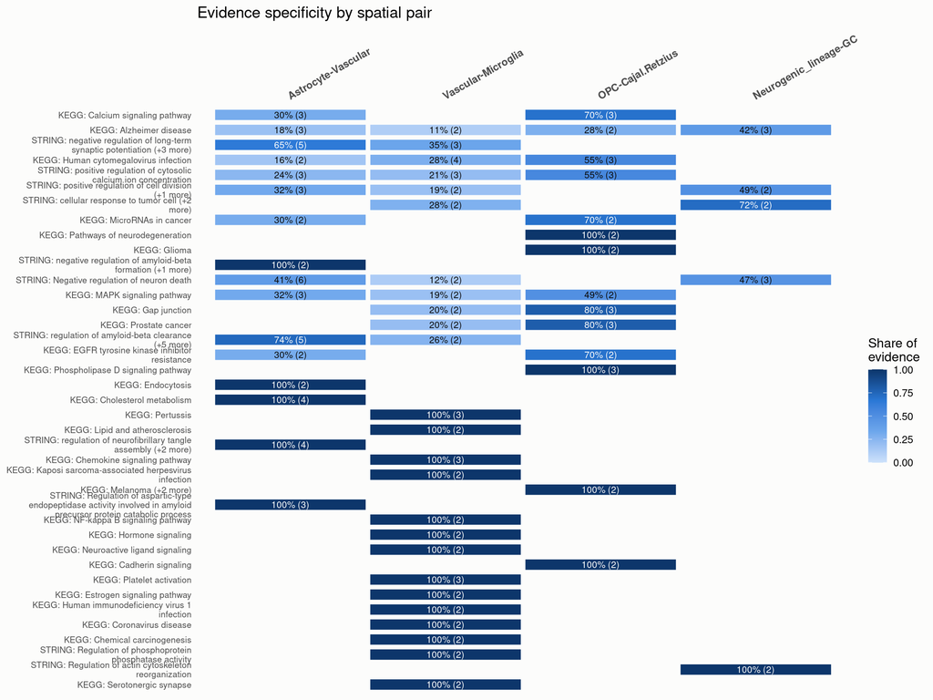

```r
specificity_heatmap_data <- pair_function_specificity %>%
  filter(function_id %in% unique(heatmap_data$function_id)) %>%
  mutate(function_label = factor(function_label, levels = rev(function_order)))

ggplot(specificity_heatmap_data, aes(x = spatial_pair, y = function_label, fill = specificity_score)) +
  geom_tile(colour = "#fcfcfb", linewidth = 2) +
  geom_text(aes(label = paste0(scales::percent(specificity_score, accuracy = 1), " (", n_genes, ")"),
                colour = specificity_score > 0.6), size = 3, show.legend = FALSE) +
  scale_fill_gradientn(colours = c("#cde2fb", "#6da7ec", "#2a78d6", "#0d366b"),
                        limits = c(0, 1), name = "Share of\nevidence") +
  scale_colour_manual(values = c(`TRUE` = "#fcfcfb", `FALSE` = "#0b0b0b")) +
  scale_x_discrete(position = "top", limits = spatial_pair_order) +
  scale_y_discrete(labels = scales::label_wrap(45)) +   # wrap long term names
  labs(x = NULL, y = NULL, title = "Evidence specificity by spatial pair") +
  theme_minimal(base_size = 12) +
  theme(
    panel.grid  = element_blank(),
    axis.text.x = element_text(face = "bold", angle = 30, hjust = 0, vjust = 0),
    axis.text.y = element_text(size = 8),
    plot.title  = element_text(margin = margin(b = 10)),
    plot.background  = element_rect(fill = "#fcfcfb", colour = NA),
    panel.background = element_rect(fill = "#fcfcfb", colour = NA)
  )
```

## 13 Notes on interpretation

- `specificity_score` describes how the evidence for a function is distributed across pairs; it is not a significance test. With 2–3 genes per cell, one gene changes it a lot, so read it together with `n_genes`.
- A function shared by 2+ pairs means their genes implicate the same broader biology, not that the LR pairs interact with each other.
- KEGG membership (curated, no test) and STRING GO enrichment (over-representation test on the whole gene set) are different kinds of evidence; a function supported by both is stronger. Genes with weak enrichment signal can be missing from the STRING side.
- “(+N more)” rows are merged terms: see `kegg_signature_groups`, `string_signature_groups` and `string_id_to_group` for what was merged.
- The heatmap is a display filter only; `function_convergence` and `pair_function_specificity` contain every function.